# State Highways: Daily Emissions

```r
test_that("Link 0 has expected values in `traffic_volumes`", {

  expect_that(
    traffic_volumes %>% filter(lnk_id == "L0", year == 2009) %>% with(., sum(AADT)),
    equals(81000), label = "Link 0, 2009: sum(AADT)")

  expect_that(
    traffic_volumes %>% filter(lnk_id == "L0", year == 2009) %>% with(., sum(VMT)),
    equals(81000 * 2.117, tol = 0.001), label = "Link 0, 2009: VMT")

})
```

```r
VEHICLE_CLASSES <- c(
  "LDA", "LDT1", "LDT2", "MDV", "LHDT1", "LHDT2",
  "MHDT", "HHDT", "UBUS", "SBUS", "OBUS", "MH", "MCY")
```

## EMFAC2014 estimates

Our first step is to construct `EMFAC_VMT_data`: a table providing estimates of (daily) `VMT` for any given `year`, `county`, `speed`, and `fleet` mix.

> We consider **LHDT2, MHDT, HHDT** classes (EMFAC2014) and `TRUCK` (in our traffic data) to be equivalent.

```r
decode_speed_indexes <- function (.data, bins = MPH_BINS) {
  speed_levels <- 5 * seq_along(bins)
  speed_labels <- bins
  .data %>%
    mutate(speed = ordered(speed, speed_levels, speed_labels)) %>%
    ensure(!any(is.na(.$speed)))
}
```

```r
standardize_EMFAC_variables <- function (.data) {
  preferred <- c(year = "CalYr", speed = "Speed", fuel = "Fuel",
                 pollutant = "Pollutant", mode = "Mode",
                 veh_class = "VehClass")
  .data %>%
    rename_(.dots = preferred[na.omit(match(names(.data), preferred))]) %>%
    mutate(county = decode(Region, DST_COUNTY_REGIONS, warn = FALSE)) %>%
    select(-Region)
}
```

```r
EMFAC_VMT_data <-
  EMFAC2014_speedwise_data %>%
  filter(VMT > 0) %>%
  standardize_EMFAC_variables() %>%
  decode_speed_indexes() %>%
  select(county, year, veh_class, speed, fuel, VMT) %>%
  distinct() %>%
  group_by(year, speed, county, fuel,
           fleet = ifelse(veh_class %in% TRUCK_CLASSES[[layer_name]],
                          yes = "TRUCK", no = "NON")) %>%
  total_each(VMT) %>%
  ungroup() %>%
  with_comment("VMT from EMFAC2014-v1.07 (RUNEX only).")
```

```r
set.seed(1)

test_VMT_data <-
  EMFAC_VMT_data %>% ungroup() %>%
  { bind_rows(sample_n(., 4), filter(., county == "SF", speed == "20-25 MPH", year == SAMPLE_YEAR)) } %>%
  with_comment("Test cases for composite VMT. Basis: EMFAC2014-v1.07")

test_VMT_data %>% copydat::Copy()
test_VMT_data %>% print_tbl(digits = 0)
```

Test cases for composite VMT. Basis: EMFAC2014-v1.07

| year | speed | county | fuel | fleet | VMT |
| --- | --- | --- | --- | --- | --- |
| 2005 | 35-40 MPH | SF | DSL | TRUCK | 31,385 |
| 2007 | 50-55 MPH | SM | DSL | NON | 20,399 |
| 2012 | 0-5 MPH | NAP | DSL | NON | 1,431 |
| 2019 | 0-5 MPH | SOL | GAS | TRUCK | 728 |
| 2014 | 20-25 MPH | SF | DSL | NON | 26,955 |
| 2014 | 20-25 MPH | SF | DSL | TRUCK | 16,355 |
| 2014 | 20-25 MPH | SF | GAS | NON | 1,748,456 |
| 2014 | 20-25 MPH | SF | GAS | TRUCK | 4,714 |

```r
# Expect about 2.4 million VMT/day for DSL trucks, Alameda, 2015
with(EMFAC_VMT_data %>% filter(year == 2015, county == "ALA", fleet == "TRUCK", fuel == "DSL"), {
  expect_equal(total(VMT), 2.40e6, tol = 1e-2)
})
```

### Check 1: CO2 and VMT totals

Our first QA/QC check on our (tidied) EMFAC2014 data is just VMT and CO2 totals.

```r
#
# QA/QC: CO2 and VMT
#
EMFAC_CO2_data <-
  EMFAC2014_speedwise_data %>%
  standardize_EMFAC_variables %>%
  decode_speed_indexes() %>%
  filter(pollutant == "CO2") %>%
  group_by(year, county) %>%
  total_each(Tons) %>%
  ungroup()

EMFAC_CO2_data %>%
  filter(year == 2015) %>%
  with_comment("Daily CO2 emissions.") %>%
  print_tbl(digits = 0, column_totals = TRUE)
```

Daily CO2 emissions.

| year | county | Tons |
| --- | --- | --- |
| 2015 | ALA | 20,432 |
| 2015 | CC | 11,178 |
| 2015 | MAR | 3,539 |
| 2015 | NAP | 1,520 |
| 2015 | SF | 4,627 |
| 2015 | SM | 7,807 |
| 2015 | SNC | 20,277 |
| 2015 | SOL | 4,616 |
| 2015 | SON | 3,596 |
|  |  | 77,592 |

```r
# Expected 2015 CO2 emissions ≈ 25.7 Tg/yr ≈ 77,600 short tons per day
with(EMFAC_CO2_data %>% filter(year == 2015), {
  expect_equal(total(Tons), 77600, tol = 1e-2)
})
```

### Check 2: Speedwise distributions

As a second, check, let’s compare speedwise EMFAC2014 distributions to speedwise distributions constructed from our (shapefile-based) traffic data.

```r
combined_VMT_data <- bind_rows(
  SHS = traffic_volumes,
  EMFAC = EMFAC_VMT_data %>% semi_join(traffic_volumes, by = "year"),
  .id = "dataset")
```

```r
HIGH_SPEED <- "45-50 MPH"
```

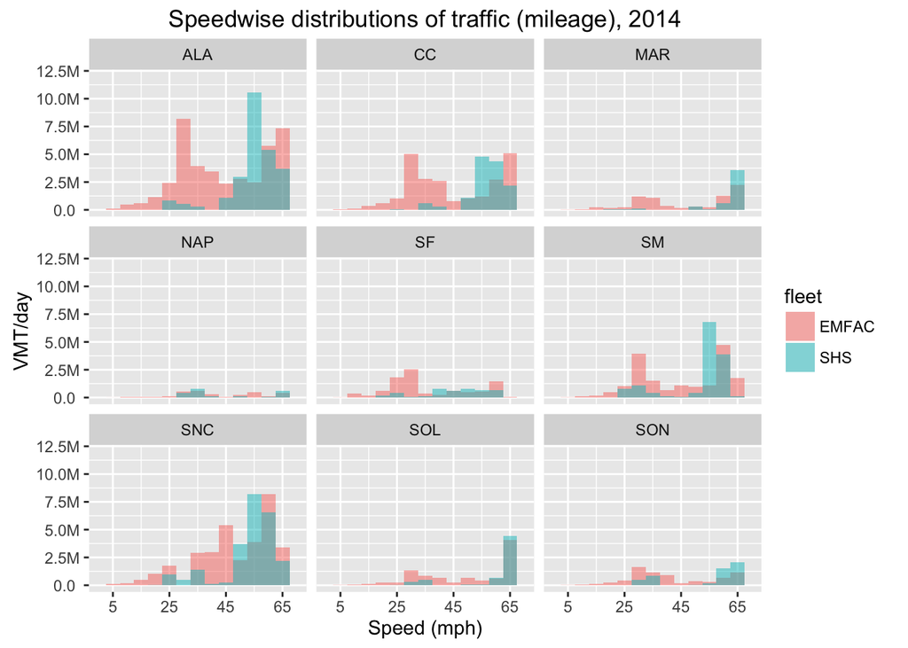

```r
SAMPLE_YEAR <- 2014
add_title <- function (.vis, ...) .vis + ggtitle(str_c(...))

speedwise_VMT_chart_data <-
  combined_VMT_data %>% filter(year == SAMPLE_YEAR) %>%
  mutate(speed = 5 * match(speed, MPH_BINS)) %>%
  group_by(dataset, county, speed, fleet) %>% total_each(VMT) %>%
  spread(fleet, VMT) %>% mutate(ALL = TRUCK + NON) %>%
  select(-NON) %>% gather(fleet, VMT, ALL, TRUCK)

add_geom_bar <- function (.vis, ...) {
  .vis + geom_bar(..., stat = "identity", position = "identity")
}

add_VMT_scale <- function (.vis, limits, ...) {
  if (missing(limits)) {
    max_observed_VMT <- max(.vis$data$VMT, na.rm = TRUE)
    limits <- c(0, max(1e6, round(max_observed_VMT, digits = -6)))
  }
  .vis + scale_y_continuous("VMT/day", limits = limits, labels = format_SI, ...)
}

add_MPH_scale <- function (.vis, ..., limits = c(0, 70), breaks = seq(5, 75, by = 20)) {
  .vis + scale_x_continuous("Speed (mph)", ..., limits = limits, breaks = breaks)
}

speedwise_VMT_chart_data %>%
  group_by(dataset, county, speed) %>% total_each(VMT) %>% # OR: filter(fleet == "TRUCK") %>%
  ggplot(aes(x = speed, y = VMT, fill = fleet)) %>%
  add(facet_wrap(~ county, ncol = 3, nrow = 3)) %>%
  add_geom_bar(aes(fill = dataset), width = 5, alpha = I(0.5)) %>%
  add_MPH_scale() %>%
  add_VMT_scale() %>%
  add_title("Speedwise distributions of traffic (mileage), ", SAMPLE_YEAR)
```

```r
combined_VMT_data %>%
  filter(year == SAMPLE_YEAR) %>%
  filter(speed >= HIGH_SPEED) %>%
  group_by(year, dataset, county) %>% total_each(VMT) %>%
  spread(dataset, VMT) %>%
  mutate(net_diff = SHS - EMFAC) %>%
  with_comment("Vehicle-miles per day (high speeds only).") %>%
  print_tbl(digits = 0, column_totals = TRUE)
```

Vehicle-miles per day (high speeds only).

| year | county | EMFAC | SHS | net_diff |
| --- | --- | --- | --- | --- |
| 2014 | ALA | 17,749,247 | 21,294,869 | 3,545,622 |
| 2014 | CC | 9,780,540 | 11,926,610 | 2,146,070 |
| 2014 | MAR | 3,986,835 | 4,302,695 | 315,860 |
| 2014 | NAP | 1,230,070 | 769,787 | -460,283 |
| 2014 | SF | 2,685,933 | 2,064,915 | -621,018 |
| 2014 | SM | 8,397,404 | 10,887,833 | 2,490,429 |
| 2014 | SNC | 17,240,510 | 19,719,995 | 2,479,485 |
| 2014 | SOL | 5,617,548 | 5,014,466 | -603,082 |
| 2014 | SON | 2,371,249 | 3,610,411 | 1,239,162 |
| 2014 |  | 69,059,336 | 79,591,581 | 10,532,245 |

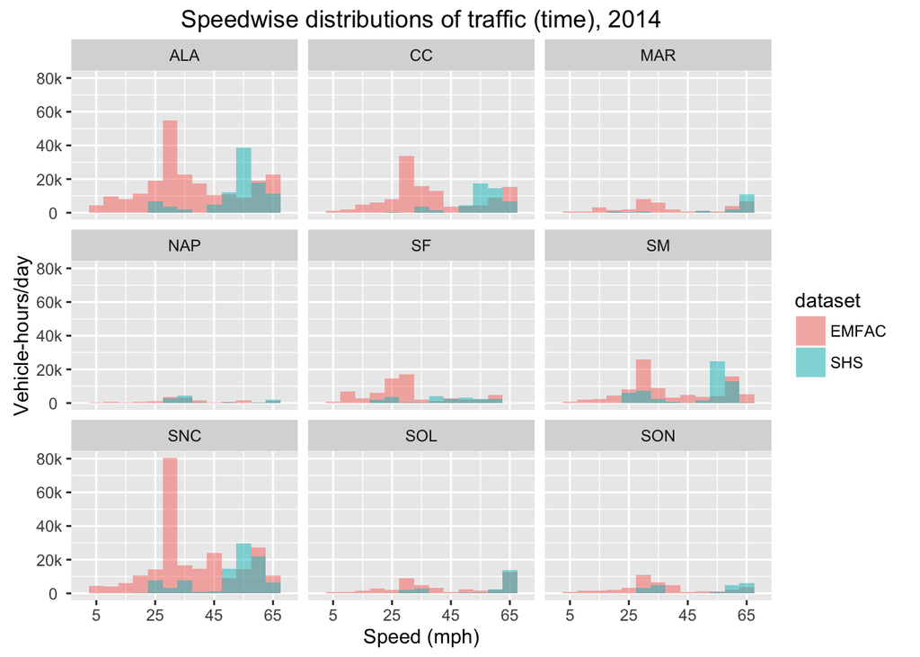

```r
speedwise_duration_chart_data <-
  speedwise_VMT_chart_data %>%
  mutate(duration = VMT / (5 * as.integer(speed))) %>%
  group_by(dataset, county, speed) %>%
  total_each(duration)

speedwise_duration_chart_data %>%
  ggplot(aes(speed, duration)) %>%
  add(facet_wrap(~ county, ncol = 3, nrow = 3)) %>%
  add_geom_bar(aes(fill = dataset), width = 5, alpha = I(0.5)) %>%
  add_MPH_scale() %>%
  add(scale_y_continuous("Vehicle-hours/day", labels = format_SI)) %>%
  add_title("Speedwise distributions of traffic (time), ", SAMPLE_YEAR)
```

```r
speedwise_duration_chart_data %>%
  group_by(dataset, speed) %>%
  total_each(duration) %>%
  filter(speed >= HIGH_SPEED) %>%
  spread(dataset, duration) %>%
  with_comment("Vehicle-hours per day (high speeds only).") %>%
  print_tbl(digits = 0, column_totals = TRUE)
```

Vehicle-hours per day (high speeds only).

| speed | EMFAC | SHS |
| --- | --- | --- |
| 5 | 14,459 |  |
| 50 | 36,070 | 37,977 |
| 55 | 38,629 | 113,930 |
| 60 | 84,832 | 79,385 |
| 65 | 78,323 | 58,023 |
| 235 | 252,314 | 289,314 |

Satisifed with the alignment of the speedwise distributions (???), we construct composite `traffic_emission_factors` by simply taking the **VMT-weighted averages** of the factors in the `speedwise_RUNEX_data` and `speedwise_VMT_data` (that we harvested from EMFAC2014).

We do this by `speed`, `fuel`, and `fleet`, as well as by `county` and `year`.

> It’s possible that we are trading too much bias for variance here — it might be better to smooth across different ranges (or the entire range of) `speed`. Or to smooth along other/additional dimensions!

```r
speedwise_emission_tbl <-
  EMFAC2014_speedwise_data %>%
  standardize_EMFAC_variables() %>%
  decode_speed_indexes() %>%
  group_by(year, speed, county, fuel, pollutant, mode,
           fleet = ifelse(veh_class %in% TRUCK_CLASSES[[layer_name]],
                          yes = "TRUCK", no = "NON")) %>%
  summarise(Tons = total(Tons), # weighted.mean(Rate, w = VMT),
            VMT = total(VMT)) %>%
  ungroup() %>%
  spread(pollutant, Tons, fill = NA) %>%
  select(year, county, fleet, fuel, mode, speed, everything()) %>%
  with_comment("Daily emissions and VMT by year, county, fleet, fuel, mode, speed, and pollutant.")
```

```r
tripwise_emission_tbl <-
  EMFAC2014_tripwise_data %>%
  standardize_EMFAC_variables() %>%
  group_by(year, county, fuel, pollutant, mode,
           fleet = ifelse(veh_class %in% TRUCK_CLASSES[[layer_name]],
                          yes = "TRUCK", no = "NON")) %>%
  summarise(Tons = total(Tons), #weighted.mean(Rate, w = VMT),
            VMT = total(VMT)) %>%
  ungroup() %>%
  spread(pollutant, Tons, fill = NA) %>%
  select(year, county, fleet, fuel, mode, everything()) %>%
  with_comment("Daily emissions and VMT by year, county, fleet, fuel, mode, and pollutant.")
```

```r
set.seed(1)

GRAMS_PER_TON <- 907185 # short ton, not metric ton
EMFAC_POLLUTANTS <- c("CO", "CO2", "NOx", "PM10", "PM2.5", "ROG", "TOG")

test_data <- speedwise_emission_tbl %>% ungroup() %>%
  { bind_rows(sample_n(., 4), filter(., county == "SF", speed == "20-25 MPH", year == SAMPLE_YEAR)) } %>%
  mutate_each(funs(. / VMT * GRAMS_PER_TON), one_of(EMFAC_POLLUTANTS)) %>%
  with_comment("Test cases for composite RUNEX factors. Basis: EMFAC2014-v1.07")

test_data %>% copydat::Copy()
test_data %>% print_tbl(digits = 3)
```

Test cases for composite RUNEX factors. Basis: EMFAC2014-v1.07

| year | county | fleet | fuel | mode | speed | VMT | CO | CO2 | NOx | PM10 | PM2.5 | ROG | TOG |
| --- | --- | --- | --- | --- | --- | --- | --- | --- | --- | --- | --- | --- | --- |
| 2005 | SON | TRUCK | DSL | RUNEX | 40-45 MPH | 39,180.808 | 2.481 | 1,415.056 | 14.256 | 0.426 | 0.408 | 0.602 | 0.690 |
| 2007 | SM | NON | GAS | RUNEX | 60-65 MPH | 1,711,642.637 | 2.636 | 405.970 | 0.345 | 0.003 | 0.003 | 0.105 | 0.133 |
| 2012 | NAP | TRUCK | GAS | RUNEX | 0-5 MPH | 341.221 | 14.431 | 1,970.224 | 1.659 | 0.013 | 0.012 | 1.160 | 1.609 |
| 2019 | ALA | TRUCK | DSL | RUNEX | 5-10 MPH | 73,311.278 | 3.240 | 2,476.390 | 11.670 | 0.090 | 0.086 | 0.897 | 1.306 |
| 2014 | SF | NON | DSL | RUNEX | 20-25 MPH | 26,954.656 | 0.663 | 569.005 | 2.091 | 0.041 | 0.039 | 0.107 | 0.124 |
| 2014 | SF | TRUCK | DSL | RUNEX | 20-25 MPH | 16,355.132 | 1.466 | 1,486.700 | 6.809 | 0.167 | 0.159 | 0.405 | 0.534 |
| 2014 | SF | NON | GAS | RUNEX | 20-25 MPH | 1,748,456.017 | 1.779 | 447.405 | 0.165 | 0.002 | 0.002 | 0.078 | 0.101 |
| 2014 | SF | TRUCK | GAS | RUNEX | 20-25 MPH | 4,714.464 | 5.344 | 1,138.665 | 1.021 | 0.002 | 0.002 | 0.220 | 0.310 |

```r
test_that("Annual VMT and CO2 emissions are as expected", {

  with(filter(speedwise_emission_tbl, year == 2015), {
    expect_equal(total(VMT), 160e6, tol = 1e-2)   # ≈ 160 million VMT/day, as before
    expect_equal(total(CO2), 70e9 / GRAMS_PER_TON, tol = 1e-2) # ≈ 0.070 Tg/day CO2, as before
  })

})
```

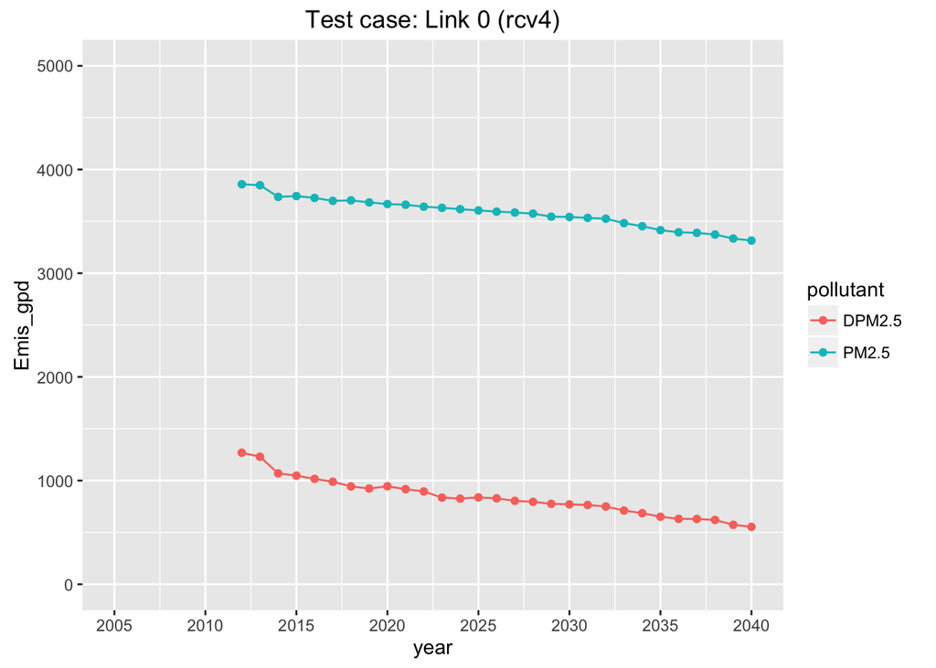

```r
test_data <- function (...) {
  speedwise_emission_tbl %>% filter(...) %>% ensure(nrow(.) == 1)
}

test_that("(ALA, 2015, 25 mph, TRUCK, DSL) -> (VMT, CO2)", {
  with(test_data(county == "ALA", year == 2015, speed == "20-25 MPH", fleet == "TRUCK", fuel == "DSL"), {
    expect_equal(VMT, 122e3, tol = 0.01)  # ≈ 0.1M VMT/day
    expect_equal(CO2, 198e6 / GRAMS_PER_TON, tol = 0.01) # ≈ 0.2G gCO2/day
  })
})

#test_that("(SF, 2009, 25 mph, DSL, ALA) -> (VMT, CO2)", {
#  with(test_data(county == "SF", year == 2009, speed == "20-25 MPH", fleet == "NON", fuel == "DSL"), {
#    expect_equal(VMT * NOx, stop("FIXME"), tol = 1e-2)
#    expect_equal(CO2, stop("FIXME") / GRAMS_PER_TON, tol = 1e-2) # ≈ 0.2 Gg CO2/day (25MPH DSL trucks, ALA)
#  })
#})

if (!exists("rcv4_env")) rcv4_env <- new.env()
load(project_path("test", "Emis.PM.Rdata"), envir = rcv4_env)
rcv4_env$Emis.PM %>% rename(lnk_id = STI_ID) %>% filter(lnk_id == 0, pollutant %in% c("PM2.5", "DPM2.5")) %>%
  qplot(year, Emis_gpd, color = pollutant, data = ., geom = c("point", "line"), main = "Test case: Link 0 (rcv4)",
        ylim = c(0, 5000)) + scale_x_continuous(limits = c(2005, 2040), breaks = seq(2000, 2040, by = 5))
```

```r
saveRDS(speedwise_emission_tbl, file = build_path(layer_name, prefixed("daily_emissions-speedwise.Rds")))
saveRDS(tripwise_emission_tbl, file = build_path(layer_name, prefixed("daily_emissions-tripwise.Rds")))
```

# Fuel fractions

**The missing bits (in the shapefile-based traffic data) are the fuel breakdowns** (conditional on `fleet` and `speed`). If it had that, we’d be able to align our models at a more detailed/granular level.

Since it’s missing, we’ll impute fuel fractions by using statistics calculated from the EMFAC2014 data. Specifically, we’ll estimate the fraction of VMT attributable to a given fuel (e.g. `DSL` or `GAS`) among vehicles of a given `fleet` traveling at a given `speed` within a given `year` and `county`.

> This might be trading too much bias for variance — we might want to smooth over `speed` or `fleet` when we estimate these `fuel_fractions`.

```r
fractions_of_VMT_by <- function (.data, ..., fill = 0.0) {
  totaled <- .data %>% group_by(..., add = TRUE) %>% summarise(VMT = total(VMT))
  fractions <- totaled %>% mutate(VMT = VMT / total(VMT))
  fractions %>% spread(..., VMT, fill = fill)
}

# ELEC, but no speeds
tripwise_fuel_fractions <-
  filter(tripwise_emission_tbl, mode == "TOTAL") %>%
  group_by(county, year, fleet) %>%
  fractions_of_VMT_by(fuel)

# no ELEC (but does have speeds)
speedwise_fuel_fractions <-
  speedwise_emission_tbl %>%
  ensure(all_true(.$mode == "RUNEX")) %>%
  group_by(county, year, speed, fleet) %>%
  fractions_of_VMT_by(fuel)
```

# III. Link-level emissions

For each link, we apportion the `VMT` from `traffic_volumes` using both (a) `tripwise_fuel_fractions` or (a) `speedwise_fuel_fractions`, for the purposes of calculating contributions from (a) brake & tire wear, as well as (b) running losses (evaporation) and exhaust.

Then we use `emission_factors` to estimate daily emissions of each pollutant attributable to each link from **wear*, **running losses**, and **exhaust**.

We store the per-link emission estimates in a column called `ems_qty` (`g/day`), indexed by `lnk_id`, `county`, `year`, `speed`, `fleet`, `fuel`, and `pollutant`. (We’ll use these results very soon to rescale our “tracer concentrations” — computed on a per-link basis — before summing the contributions from multiple links to individual receptors).

As a bit of QA/QC, we construct and use a helper function called `ensure_emissions_total` to verify a few subtotals right at the end.

```r
# For on-the-fly verification of emission subtotal(s)
ensure_emissions_total <- function (.data, .pol, .year, qty, unit, ...) {
  filtered <- filter(.data, year == .year, pollutant == .pol)
  stopifnot(all(filtered$ems_unit == unit))
  stopifnot(all.equal(total(filtered$ems_qty), qty, ...))
  return(.data)
}
```

```r
# Let `apply_fractions` be the same thing as `apply_scalars`.
# (Just makes it easier to read the intent of our code.)
apply_fractions <- inventory::apply_scalars
```

```r
EMFAC_POLLUTANTS <- c("CO", "CO2", "NOx", "PM10", "PM2.5", "ROG", "TOG", "SOx")
```

## Tire and brake wear (PM2.5 only)

```r
WEAR_MODES <- c("PMTW", "PMBW")

wear_rate_tbl <-
  tripwise_emission_tbl %>%
  filter(mode %in% WEAR_MODES) %>%
  select(-one_of(setdiff(EMFAC_POLLUTANTS, "PM2.5"))) %>%
  mutate_each(funs(. / VMT * GRAMS_PER_TON), PM2.5) %>%
  select(-VMT) %>%
  spread(mode, PM2.5) %>%
  with_comment("Tripwise emission rates (g/veh-mi). Basis: EMFAC2014-v1.07")

lnk_wear_emissions <-
  traffic_volumes %>%
  select(county, lnk_id, year, speed, fleet, VMT) %>%
  apply_fractions(tripwise_fuel_fractions, "VMT", "fuel") %>% # apportion (State Highway) speedwise VMT by (EMFAC) speedwise fuel fraction
  apply_scalars(wear_rate_tbl, "VMT") %>%  # multiply VMT by emission factors
  gather(mode, ems_qty, one_of(WEAR_MODES)) %>%
  mutate(pollutant = "PM2.5") %>%
  mutate(ems_unit = "g/day") %>%
  filter(ems_qty > 0)

lnk_wear_emissions %>%
  filter(lnk_id == "L0", year == SAMPLE_YEAR)
```

```
## Source: local data frame [10 x 10]
##
##    county lnk_id  year     speed fleet  fuel  mode      ems_qty pollutant
##     <chr>  <chr> <int>     <chr> <chr> <chr> <chr>        <dbl>     <chr>
## 1      SF     L0  2014 20-25 MPH   NON   DSL  PMTW   10.2191262     PM2.5
## 2      SF     L0  2014 20-25 MPH TRUCK   DSL  PMTW    9.2180290     PM2.5
## 3      SF     L0  2014 20-25 MPH   NON  ELEC  PMTW    0.8069939     PM2.5
## 4      SF     L0  2014 20-25 MPH   NON   GAS  PMTW  294.7019271     PM2.5
## 5      SF     L0  2014 20-25 MPH TRUCK   GAS  PMTW    1.0803135     PM2.5
## 6      SF     L0  2014 20-25 MPH   NON   DSL  PMBW  512.8450955     PM2.5
## 7      SF     L0  2014 20-25 MPH TRUCK   DSL  PMBW   94.5713744     PM2.5
## 8      SF     L0  2014 20-25 MPH   NON  ELEC  PMBW    6.3550772     PM2.5
## 9      SF     L0  2014 20-25 MPH   NON   GAS  PMBW 2386.1637020     PM2.5
## 10     SF     L0  2014 20-25 MPH TRUCK   GAS  PMBW   19.6974521     PM2.5
## Variables not shown: ems_unit <chr>.
```

## Running losses

```r
RUNLOSS_MODE <- c("RUNLS")

runloss_rate_tbl <-
  tripwise_emission_tbl %>%
  filter(mode == RUNLOSS_MODE) %>%
  mutate_each(funs(. / VMT * GRAMS_PER_TON), one_of(intersect(EMFAC_POLLUTANTS, names(.)))) %>%
  select(-VMT, -mode) %>%
  with_comment("Tripwise emission rates (g/veh-mi). Basis: EMFAC2014-v1.07")

lnk_runloss_emissions <-
  traffic_volumes %>%
  select(county, lnk_id, year, speed, fleet, VMT) %>%
  apply_fractions(tripwise_fuel_fractions, "VMT", "fuel") %>% # apportion (State Highway) speedwise VMT by (EMFAC) speedwise fuel fraction
  apply_scalars(runloss_rate_tbl, "VMT") %>%  # multiply VMT by emission factors
  gather(pollutant, ems_qty, one_of(intersect(EMFAC_POLLUTANTS, names(.)))) %>%
  mutate(ems_unit = "g/day") %>%
  mutate(mode = RUNLOSS_MODE) %>%
  filter(ems_qty > 0)

# TODO: test case(s)
```

## Exhaust (all pollutants)

```r
exhaust_rate_tbl <-
  speedwise_emission_tbl %>%
  ensure(all_true(.$mode == "RUNEX")) %>%
  mutate_each(funs(. / VMT * GRAMS_PER_TON), one_of(intersect(EMFAC_POLLUTANTS, names(.)))) %>%
  select(-mode, -VMT) %>%
  with_comment("Speedwise emission rates (g/veh-mi). Basis: EMFAC2014-v1.07")

lnk_exhaust_emissions <-
  traffic_volumes %>%
  select(county, lnk_id, year, speed, fleet, VMT) %>%
  apply_fractions(speedwise_fuel_fractions, "VMT", "fuel") %>% # apportion (State Highway) speedwise VMT by (EMFAC) speedwise fuel fraction
  apply_scalars(exhaust_rate_tbl, "VMT") %>%  # multiply VMT by emission factors
  gather(pollutant, ems_qty, one_of(intersect(EMFAC_POLLUTANTS, names(.)))) %>%
  mutate(ems_unit = "g/day") %>%
  mutate(mode = "RUNEX") %>%
  ensure_emissions_total("CO2", 2009, 3.88e10, "g/day", tol = 0.01) %>%
  ensure_emissions_total("CO2", SAMPLE_YEAR, 3.93e10, "g/day", tol = 0.01)
# Test case #1
test_that("Link 0: emission factors for running exhaust (g/day) are as expected", {

  L0_exhaust_gpd <- function (...) {
    .data <- lnk_exhaust_emissions %>% filter(lnk_id == "L0", county == "SF", year == 2009, ...)
    .data %>% ensure(nrow(.) == 1, .$ems_unit == "g/day") %>% .[["ems_qty"]]
  }

  # Link 0: 25mph CO2 RUNEX (NON-TRUCK only, DSL only)
  # - updated 2016-03-15 to reflect corrected MILES and (accordingly) corrected VMT
  #   (from STRte_BAAQMD_AADT2014 instead of STRte_BAAQMD_2014)
  expect_equal(L0_exhaust_gpd(pollutant == "CO2", fleet == "NON", fuel == "DSL", speed == "20-25 MPH"),
               1033289, tol = 0.001, label = "Link 0 25mph NON-TRUCK DSL CO2 (g/day)")

  # Link 0: 25mph PM2.5 RUNEX (NON-TRUCK & TRUCK, DSL & GAS)
  # - updated 2016-03-15 to reflect corrected MILES and (accordingly) corrected VMT
  #   (from STRte_BAAQMD_AADT2014 instead of STRte_BAAQMD_2014)
  expect_equal(L0_exhaust_gpd(pollutant == "PM2.5", fleet == "NON", fuel == "DSL", speed == "20-25 MPH"),
               223, tol = 0.01, label = "Link 0 25mph NON-TRUCK DSL PM2.5 (g/day)")
  expect_equal(L0_exhaust_gpd(pollutant == "PM2.5", fleet == "NON", fuel == "GAS", speed == "20-25 MPH"),
               635, tol = 0.01, label = "Link 0 25mph NON-TRUCK GAS PM2.5 (g/day)")
  expect_equal(L0_exhaust_gpd(pollutant == "PM2.5", fleet == "TRUCK", fuel == "DSL", speed == "20-25 MPH"),
               760, tol = 0.01, label = "Link 0 25mph TRUCK DSL PM2.5 (g/day)")
  expect_equal(L0_exhaust_gpd(pollutant == "PM2.5", fleet == "TRUCK", fuel == "GAS", speed == "20-25 MPH"),
               2.66, tol = 0.01, label = "Link 0 25mph TRUCK GAS PM2.5 (g/day)")

})
```

## Road dust

```r
dust_rate_tbl <-
  project_path("in", "emission_rates", prefixed("emission_rates-dust.csv")) %>%
  read_csv() %>%
  mutate(county = decode(Region, DST_COUNTY_REGIONS, warn = FALSE)) %>%
  select(county, matches("^PM")) %>%
  gather(metric, `g/VMT`, -county) %>%
  mutate(metric = str_uppercase(metric)) %>%
  extract(metric, into = c("mode", "fleet", "fuel"), regex = "PM2_5_([A-Z]+)_([A-Z]+)_([A-Z]+)_ER") %>%
  spread(mode, `g/VMT`)

lnk_dust_emissions <-
  traffic_volumes %>%
  select(county, lnk_id, year, speed, fleet, VMT) %>%
  apply_fractions(tripwise_fuel_fractions, "VMT", "fuel") %>% # apportion (State Highway) speedwise VMT by (EMFAC) speedwise fuel fraction
  apply_scalars(dust_rate_tbl, "VMT") %>%  # multiply VMT by emission factors
  gather(mode, ems_qty, PMRD) %>%
  mutate(pollutant = "PM2.5") %>%
  mutate(ems_unit = "g/day") %>%
  filter(ems_qty > 0)

lnk_dust_emissions %>%
  filter(lnk_id == "L0", year == SAMPLE_YEAR)
```

```
## Source: local data frame [4 x 10]
##
##   county lnk_id  year     speed fleet  fuel  mode     ems_qty pollutant
##    <chr>  <chr> <int>     <chr> <chr> <chr> <chr>       <dbl>     <chr>
## 1     SF     L0  2014 20-25 MPH   NON   DSL  PMRD   38.705668     PM2.5
## 2     SF     L0  2014 20-25 MPH TRUCK   DSL  PMRD   20.336810     PM2.5
## 3     SF     L0  2014 20-25 MPH   NON   GAS  PMRD 1469.321769     PM2.5
## 4     SF     L0  2014 20-25 MPH TRUCK   GAS  PMRD    3.929852     PM2.5
## Variables not shown: ems_unit <chr>.
```

```r
lnk_emission_data <- bind_rows(
  exhaust = lnk_exhaust_emissions,
  wear = lnk_wear_emissions,
  dust = lnk_dust_emissions,
  runloss = lnk_runloss_emissions)

lnk_emission_data %>%
  filter(lnk_id == "L0", year == SAMPLE_YEAR, pollutant == "PM2.5") %>%
  rename(lnk = lnk_id) %>%
  print_tbl(str_c("PM2.5 emissions for a selected (", layer_name, ") link."),
            digits = 0, column_totals = TRUE)
```

PM2.5 emissions for a selected (state_highways) link.

| county | lnk | year | speed | fleet | fuel | pollutant | ems_qty | ems_unit | mode |
| --- | --- | --- | --- | --- | --- | --- | --- | --- | --- |
| SF | L0 | 2014 | 20-25 MPH | NON | DSL | PM2.5 | 91 | g/day | RUNEX |
| SF | L0 | 2014 | 20-25 MPH | TRUCK | DSL | PM2.5 | 302 | g/day | RUNEX |
| SF | L0 | 2014 | 20-25 MPH | NON | GAS | PM2.5 | 329 | g/day | RUNEX |
| SF | L0 | 2014 | 20-25 MPH | TRUCK | GAS | PM2.5 | 1 | g/day | RUNEX |
| SF | L0 | 2014 | 20-25 MPH | NON | DSL | PM2.5 | 10 | g/day | PMTW |
| SF | L0 | 2014 | 20-25 MPH | TRUCK | DSL | PM2.5 | 9 | g/day | PMTW |
| SF | L0 | 2014 | 20-25 MPH | NON | ELEC | PM2.5 | 1 | g/day | PMTW |
| SF | L0 | 2014 | 20-25 MPH | NON | GAS | PM2.5 | 295 | g/day | PMTW |
| SF | L0 | 2014 | 20-25 MPH | TRUCK | GAS | PM2.5 | 1 | g/day | PMTW |
| SF | L0 | 2014 | 20-25 MPH | NON | DSL | PM2.5 | 513 | g/day | PMBW |
| SF | L0 | 2014 | 20-25 MPH | TRUCK | DSL | PM2.5 | 95 | g/day | PMBW |
| SF | L0 | 2014 | 20-25 MPH | NON | ELEC | PM2.5 | 6 | g/day | PMBW |
| SF | L0 | 2014 | 20-25 MPH | NON | GAS | PM2.5 | 2,386 | g/day | PMBW |
| SF | L0 | 2014 | 20-25 MPH | TRUCK | GAS | PM2.5 | 20 | g/day | PMBW |
| SF | L0 | 2014 | 20-25 MPH | NON | DSL | PM2.5 | 39 | g/day | PMRD |
| SF | L0 | 2014 | 20-25 MPH | TRUCK | DSL | PM2.5 | 20 | g/day | PMRD |
| SF | L0 | 2014 | 20-25 MPH | NON | GAS | PM2.5 | 1,469 | g/day | PMRD |
| SF | L0 | 2014 | 20-25 MPH | TRUCK | GAS | PM2.5 | 4 | g/day | PMRD |
|  |  |  |  |  |  |  | 5,591 |  |  |

```r
lnk_length_data <-
  lnk_centerlines@data %>%
  select(lnk_id, lnk_length = MILES)

which_pollutant <- "PM2.5"

map_data <-
  lnk_emission_data %>%
  filter(year == SAMPLE_YEAR) %>%
  filter(pollutant == which_pollutant) %>%
  annual_emissions_by(lnk_id, speed, pollutant, fleet) %>%
  left_join(lnk_length_data) %>%
  mutate(ems_rate = ems_qty / lnk_length) %>%
  select(-ems_qty) %>%
  spread(fleet, ems_rate) %>%
  mutate(ALL = TRUCK + NON)
# Join to `lnk_centerlines` and reproject to (lon, lat)
map_layer <-
  merge_SpatialDataFrame(lnk_centerlines, map_data, by = "lnk_id") %>%
  reproject(WGS84)

popup_default <- function (...) str_c("<p>", ..., "</p>")
popup_for_link <- function (lnk_id, speed, ALL, TRUCK) {
  sprintf("<p><b>Link %s</b> </br> %s MPH</p> <p><b>%s (per day):</b> <br/> ALL: %0.0f g/mi </br> TRUCK: %0.0f g/mi</p>",
          lnk_id, speed, which_pollutant, ALL, TRUCK)
}

# Render a nice map
leaflet(map_layer) %>%
  addProviderTiles('CartoDB.Positron') %>%
  addPolylines(weight = ~(ALL / 300),
               color = gray(0.3), opacity = 1.0,
               popup = ~popup_for_link(lnk_id, speed, ALL, TRUCK)) %>%
  addPolylines(weight = ~(TRUCK / 300),
               color = "orange", opacity = 1.0,
               popup = ~popup_for_link(lnk_id, speed, ALL, TRUCK))
```

[interactive chart not shown]

```r
write_csv(
  tripwise_fuel_fractions %>% mutate_each(funs(round(., digits = 5)), DSL, ELEC, GAS),
  build_path(layer_name, prefixed("fuel_fractions-tripwise.csv")))

write_csv(
  speedwise_fuel_fractions %>% mutate_each(funs(round(., digits = 5)), DSL, GAS),
  build_path(layer_name, prefixed("fuel_fractions-speedwise.csv")))

write_csv(
  exhaust_rate_tbl %>% mutate_each(funs(round(., digits = 5)), CO, CO2, NOx, PM10, PM2.5, ROG, TOG),
  build_path(layer_name, prefixed("emission_factors-exhaust.csv")))

write_csv(
  runloss_rate_tbl %>% mutate_each(funs(round(., digits = 5)), CO, CO2, NOx, PM10, PM2.5, ROG, TOG, SOx),
  build_path(layer_name, prefixed("emission_factors-runloss.csv")))

write_csv(
  wear_rate_tbl %>% mutate_each(funs(round(., digits = 5)), one_of(WEAR_MODES)),
  build_path(layer_name, prefixed("emission_factors-wear.csv")))

write_csv(
  dust_rate_tbl %>% mutate_each(funs(round(., digits = 5)), PMRD),
  build_path(layer_name, prefixed("emission_factors-dust.csv")))

write_csv(
  lnk_emission_data %>% mutate(ems_qty = round(ems_qty, digits = 2)),
  build_path(layer_name, prefixed("daily_emissions.csv")))
```